# Optimal Treatment Analysis

## Outcome Variable

**Outcome Variable:** haz

## Predictor Variables

**Intervention Variable:** pers_wast

**Adjustment Set:**

- arm
- sex
- brthmon
- W_mage
- meducyrs
- hhwealth_quart
- W_nrooms
- month
- W_parity
- delta_W_mage
- delta_meducyrs
- delta_hhwealth_quart
- delta_W_nrooms
- delta_month
- delta_W_parity

## Stratifying Variables

The analysis was stratified on these variable(s):

- agecat
- studyid
- country

## Data Summary

| agecat | studyid | country | pers_wast | n_cell | n |
| --- | --- | --- | --- | --- | --- |
| Birth | CMC-V-BCS-2002 | INDIA | 0 | 80 | 92 |
| Birth | CMC-V-BCS-2002 | INDIA | 1 | 12 | 92 |
| Birth | CMIN | BANGLADESH | 0 | 16 | 18 |
| Birth | CMIN | BANGLADESH | 1 | 2 | 18 |
| Birth | CONTENT | PERU | 0 | 2 | 2 |
| Birth | CONTENT | PERU | 1 | 0 | 2 |
| Birth | EE | PAKISTAN | 0 | 224 | 240 |
| Birth | EE | PAKISTAN | 1 | 16 | 240 |
| Birth | GMS-Nepal | NEPAL | 0 | 521 | 585 |
| Birth | GMS-Nepal | NEPAL | 1 | 64 | 585 |
| Birth | IRC | INDIA | 0 | 319 | 387 |
| Birth | IRC | INDIA | 1 | 68 | 387 |
| Birth | Keneba | GAMBIA | 0 | 1374 | 1419 |
| Birth | Keneba | GAMBIA | 1 | 45 | 1419 |
| Birth | MAL-ED | BANGLADESH | 0 | 220 | 229 |
| Birth | MAL-ED | BANGLADESH | 1 | 9 | 229 |
| Birth | MAL-ED | BRAZIL | 0 | 65 | 65 |
| Birth | MAL-ED | BRAZIL | 1 | 0 | 65 |
| Birth | MAL-ED | INDIA | 0 | 43 | 45 |
| Birth | MAL-ED | INDIA | 1 | 2 | 45 |
| Birth | MAL-ED | NEPAL | 0 | 26 | 27 |
| Birth | MAL-ED | NEPAL | 1 | 1 | 27 |
| Birth | MAL-ED | PERU | 0 | 233 | 233 |
| Birth | MAL-ED | PERU | 1 | 0 | 233 |
| Birth | MAL-ED | SOUTH AFRICA | 0 | 111 | 113 |
| Birth | MAL-ED | SOUTH AFRICA | 1 | 2 | 113 |
| Birth | MAL-ED | TANZANIA, UNITED REPUBLIC OF | 0 | 123 | 123 |
| Birth | MAL-ED | TANZANIA, UNITED REPUBLIC OF | 1 | 0 | 123 |
| Birth | PROVIDE | BANGLADESH | 0 | 516 | 539 |
| Birth | PROVIDE | BANGLADESH | 1 | 23 | 539 |

[output cut: 70 more lines]

The following strata were considered:

- agecat: 24 months, studyid: CMC-V-BCS-2002, country: INDIA
- agecat: 24 months, studyid: CMIN, country: BANGLADESH
- agecat: 24 months, studyid: CONTENT, country: PERU
- agecat: 24 months, studyid: EE, country: PAKISTAN
- agecat: 24 months, studyid: GMS-Nepal, country: NEPAL
- agecat: 24 months, studyid: IRC, country: INDIA
- agecat: 24 months, studyid: Keneba, country: GAMBIA
- agecat: 24 months, studyid: MAL-ED, country: BANGLADESH
- agecat: 24 months, studyid: MAL-ED, country: BRAZIL
- agecat: 24 months, studyid: MAL-ED, country: INDIA
- agecat: 24 months, studyid: MAL-ED, country: NEPAL
- agecat: 24 months, studyid: MAL-ED, country: PERU
- agecat: 24 months, studyid: MAL-ED, country: SOUTH AFRICA
- agecat: 24 months, studyid: MAL-ED, country: TANZANIA, UNITED REPUBLIC OF
- agecat: 24 months, studyid: PROVIDE, country: BANGLADESH
- agecat: 24 months, studyid: TanzaniaChild2, country: TANZANIA, UNITED REPUBLIC OF
- agecat: 6 months, studyid: CMC-V-BCS-2002, country: INDIA
- agecat: 6 months, studyid: CMIN, country: BANGLADESH
- agecat: 6 months, studyid: CONTENT, country: PERU
- agecat: 6 months, studyid: EE, country: PAKISTAN
- agecat: 6 months, studyid: GMS-Nepal, country: NEPAL
- agecat: 6 months, studyid: Guatemala BSC, country: GUATEMALA
- agecat: 6 months, studyid: IRC, country: INDIA
- agecat: 6 months, studyid: Keneba, country: GAMBIA
- agecat: 6 months, studyid: MAL-ED, country: BANGLADESH
- agecat: 6 months, studyid: MAL-ED, country: BRAZIL
- agecat: 6 months, studyid: MAL-ED, country: INDIA
- agecat: 6 months, studyid: MAL-ED, country: NEPAL
- agecat: 6 months, studyid: MAL-ED, country: PERU
- agecat: 6 months, studyid: MAL-ED, country: SOUTH AFRICA
- agecat: 6 months, studyid: MAL-ED, country: TANZANIA, UNITED REPUBLIC OF
- agecat: 6 months, studyid: PROVIDE, country: BANGLADESH
- agecat: 6 months, studyid: ResPak, country: PAKISTAN
- agecat: 6 months, studyid: TanzaniaChild2, country: TANZANIA, UNITED REPUBLIC OF
- agecat: Birth, studyid: CMC-V-BCS-2002, country: INDIA
- agecat: Birth, studyid: CMIN, country: BANGLADESH
- agecat: Birth, studyid: CONTENT, country: PERU
- agecat: Birth, studyid: EE, country: PAKISTAN
- agecat: Birth, studyid: GMS-Nepal, country: NEPAL
- agecat: Birth, studyid: IRC, country: INDIA
- agecat: Birth, studyid: Keneba, country: GAMBIA
- agecat: Birth, studyid: MAL-ED, country: BANGLADESH
- agecat: Birth, studyid: MAL-ED, country: BRAZIL
- agecat: Birth, studyid: MAL-ED, country: INDIA
- agecat: Birth, studyid: MAL-ED, country: NEPAL
- agecat: Birth, studyid: MAL-ED, country: PERU
- agecat: Birth, studyid: MAL-ED, country: SOUTH AFRICA
- agecat: Birth, studyid: MAL-ED, country: TANZANIA, UNITED REPUBLIC OF
- agecat: Birth, studyid: PROVIDE, country: BANGLADESH
- agecat: Birth, studyid: ResPak, country: PAKISTAN

### Dropped Strata

Some strata were dropped due to rare outcomes:

- agecat: Birth, studyid: CMIN, country: BANGLADESH
- agecat: Birth, studyid: CONTENT, country: PERU
- agecat: Birth, studyid: MAL-ED, country: BRAZIL
- agecat: Birth, studyid: MAL-ED, country: INDIA
- agecat: Birth, studyid: MAL-ED, country: NEPAL
- agecat: Birth, studyid: MAL-ED, country: PERU
- agecat: Birth, studyid: MAL-ED, country: SOUTH AFRICA
- agecat: Birth, studyid: MAL-ED, country: TANZANIA, UNITED REPUBLIC OF
- agecat: Birth, studyid: ResPak, country: PAKISTAN
- agecat: 6 months, studyid: CONTENT, country: PERU
- agecat: 6 months, studyid: MAL-ED, country: BRAZIL
- agecat: 6 months, studyid: MAL-ED, country: PERU
- agecat: 6 months, studyid: MAL-ED, country: SOUTH AFRICA
- agecat: 6 months, studyid: MAL-ED, country: TANZANIA, UNITED REPUBLIC OF
- agecat: 24 months, studyid: CONTENT, country: PERU
- agecat: 24 months, studyid: MAL-ED, country: BRAZIL
- agecat: 24 months, studyid: MAL-ED, country: PERU
- agecat: 24 months, studyid: MAL-ED, country: SOUTH AFRICA
- agecat: 24 months, studyid: MAL-ED, country: TANZANIA, UNITED REPUBLIC OF
- agecat: 24 months, studyid: TanzaniaChild2, country: TANZANIA, UNITED REPUBLIC OF

## Methods Detail

We’re interested in the causal parameters $E[Y_a]$ for all values of $a \in \mathcal{A}$. These parameters represent the mean outcome if, possibly contrary to fact, we intervened to set all units to have $A=a$. Under the randomization and positivity assumptions, these are identified by the statistical parameters $\psi_a=E_W[E_{Y|A,W}(Y|A=a,W)]$. In addition, we’re interested in the mean of $Y$, $E[Y]$ under no intervention (the observed mean). We will estimate these parameters by using SuperLearner to fit the relevant likelihood factors – $E_{Y|A,W}(Y|A=a,W)$ and $p(A=a|W)$, and then updating our likelihood fit using a joint TMLE.

For unadjusted analyses ($W=\{\}$), initial likelihoods were estimated using Lrnr_glm to estimate the simple $E(Y|A)$ and Lrnr_mean to estimate $p(A)$. For adjusted analyses, a small library containing Lrnr_glmnet, Lrnr_xgboost, and Lrnr_mean was used.

Having estimated these parameters, we will then use the delta method to estimate relative risks and attributable risks relative to a prespecified baseline level of $A$.

# Results Detail

## Results Plots

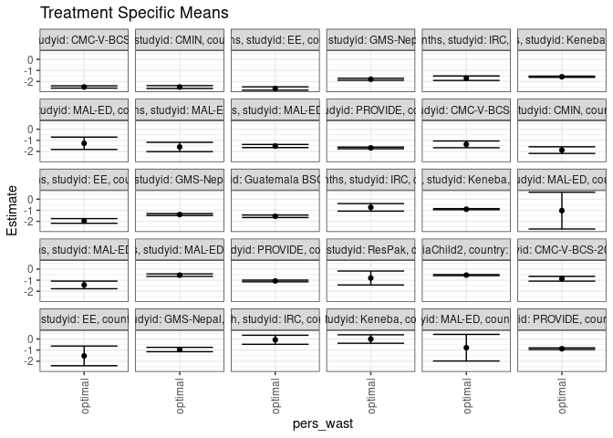

## Results Table

### Parameter: TSM

| agecat | studyid | country | intervention_level | baseline_level | estimate | ci_lower | ci_upper |
| --- | --- | --- | --- | --- | --- | --- | --- |
| Birth | CMC-V-BCS-2002 | INDIA | optimal | observed | -0.8716983 | -1.0866814 | -0.6567153 |
| Birth | EE | PAKISTAN | optimal | observed | -1.5221002 | -2.4101472 | -0.6340533 |
| Birth | GMS-Nepal | NEPAL | optimal | observed | -0.9481663 | -1.1463025 | -0.7500300 |
| Birth | IRC | INDIA | optimal | observed | -0.0667010 | -0.4734081 | 0.3400061 |
| Birth | Keneba | GAMBIA | optimal | observed | -0.0015120 | -0.3828837 | 0.3798597 |
| Birth | MAL-ED | BANGLADESH | optimal | observed | -0.7839324 | -1.9844308 | 0.4165659 |
| Birth | PROVIDE | BANGLADESH | optimal | observed | -0.8753806 | -0.9529023 | -0.7978589 |
| 6 months | CMC-V-BCS-2002 | INDIA | optimal | observed | -1.3646185 | -1.6702332 | -1.0590039 |
| 6 months | CMIN | BANGLADESH | optimal | observed | -1.8837441 | -2.1846390 | -1.5828493 |
| 6 months | EE | PAKISTAN | optimal | observed | -1.9646655 | -2.1768779 | -1.7524530 |
| 6 months | GMS-Nepal | NEPAL | optimal | observed | -1.3887518 | -1.4759093 | -1.3015943 |
| 6 months | Guatemala BSC | GUATEMALA | optimal | observed | -1.5419408 | -1.6572609 | -1.4266208 |
| 6 months | IRC | INDIA | optimal | observed | -0.7382659 | -1.0785088 | -0.3980230 |
| 6 months | Keneba | GAMBIA | optimal | observed | -0.9048476 | -0.9537356 | -0.8559597 |
| 6 months | MAL-ED | BANGLADESH | optimal | observed | -1.0314290 | -2.6910606 | 0.6282025 |
| 6 months | MAL-ED | INDIA | optimal | observed | -1.4280324 | -1.7724136 | -1.0836512 |
| 6 months | MAL-ED | NEPAL | optimal | observed | -0.5471736 | -0.6605690 | -0.4337782 |
| 6 months | PROVIDE | BANGLADESH | optimal | observed | -1.0710590 | -1.1455765 | -0.9965414 |
| 6 months | ResPak | PAKISTAN | optimal | observed | -0.8049131 | -1.4331455 | -0.1766808 |
| 6 months | TanzaniaChild2 | TANZANIA, UNITED REPUBLIC OF | optimal | observed | -0.5437456 | -0.5936463 | -0.4938448 |
| 24 months | CMC-V-BCS-2002 | INDIA | optimal | observed | -2.4957609 | -2.6004944 | -2.3910273 |
| 24 months | CMIN | BANGLADESH | optimal | observed | -2.5012719 | -2.6291582 | -2.3733856 |
| 24 months | EE | PAKISTAN | optimal | observed | -2.6366034 | -2.7880013 | -2.4852055 |
| 24 months | GMS-Nepal | NEPAL | optimal | observed | -1.7995492 | -1.8912202 | -1.7078782 |
| 24 months | IRC | INDIA | optimal | observed | -1.7053920 | -1.9064494 | -1.5043345 |
| 24 months | Keneba | GAMBIA | optimal | observed | -1.5735238 | -1.6277659 | -1.5192817 |
| 24 months | MAL-ED | BANGLADESH | optimal | observed | -1.2665209 | -1.8226509 | -0.7103910 |
| 24 months | MAL-ED | INDIA | optimal | observed | -1.5984976 | -2.0191055 | -1.1778897 |
| 24 months | MAL-ED | NEPAL | optimal | observed | -1.5132743 | -1.6545316 | -1.3720170 |
| 24 months | PROVIDE | BANGLADESH | optimal | observed | -1.6843364 | -1.7583855 | -1.6102874 |

### Parameter: E(Y)

| agecat | studyid | country | intervention_level | baseline_level | estimate | ci_lower | ci_upper |
| --- | --- | --- | --- | --- | --- | --- | --- |
| Birth | CMC-V-BCS-2002 | INDIA | observed | observed | -0.9611957 | -1.1776967 | -0.7446946 |
| Birth | EE | PAKISTAN | observed | observed | -1.8608750 | -2.0482045 | -1.6735455 |
| Birth | GMS-Nepal | NEPAL | observed | observed | -1.0554530 | -1.1411259 | -0.9697801 |
| Birth | IRC | INDIA | observed | observed | -0.3117313 | -0.4727359 | -0.1507267 |
| Birth | Keneba | GAMBIA | observed | observed | 0.0432135 | -0.0229516 | 0.1093787 |
| Birth | MAL-ED | BANGLADESH | observed | observed | -1.1041048 | -1.2383048 | -0.9699048 |
| Birth | PROVIDE | BANGLADESH | observed | observed | -0.8851020 | -0.9601332 | -0.8100709 |
| 6 months | CMC-V-BCS-2002 | INDIA | observed | observed | -1.4241872 | -1.5668135 | -1.2815609 |
| 6 months | CMIN | BANGLADESH | observed | observed | -1.7844376 | -1.9222926 | -1.6465825 |
| 6 months | EE | PAKISTAN | observed | observed | -2.0835567 | -2.2027557 | -1.9643578 |
| 6 months | GMS-Nepal | NEPAL | observed | observed | -1.3533244 | -1.4319426 | -1.2747062 |
| 6 months | Guatemala BSC | GUATEMALA | observed | observed | -1.5734843 | -1.6884116 | -1.4585570 |
| 6 months | IRC | INDIA | observed | observed | -1.2382964 | -1.3698449 | -1.1067479 |
| 6 months | Keneba | GAMBIA | observed | observed | -0.9282048 | -0.9770928 | -0.8793169 |
| 6 months | MAL-ED | BANGLADESH | observed | observed | -1.2049931 | -1.3222136 | -1.0877726 |
| 6 months | MAL-ED | INDIA | observed | observed | -1.2115254 | -1.3298727 | -1.0931782 |
| 6 months | MAL-ED | NEPAL | observed | observed | -0.5615819 | -0.6741832 | -0.4489807 |
| 6 months | PROVIDE | BANGLADESH | observed | observed | -1.0916915 | -1.1661176 | -1.0172654 |
| 6 months | ResPak | PAKISTAN | observed | observed | -1.3874523 | -1.5959323 | -1.1789723 |
| 6 months | TanzaniaChild2 | TANZANIA, UNITED REPUBLIC OF | observed | observed | -0.5450830 | -0.5941754 | -0.4959906 |
| 24 months | CMC-V-BCS-2002 | INDIA | observed | observed | -2.5489071 | -2.6476125 | -2.4502017 |
| 24 months | CMIN | BANGLADESH | observed | observed | -2.5109504 | -2.6361514 | -2.3857494 |
| 24 months | EE | PAKISTAN | observed | observed | -2.6699900 | -2.8138051 | -2.5261749 |
| 24 months | GMS-Nepal | NEPAL | observed | observed | -1.8938622 | -1.9795205 | -1.8082040 |
| 24 months | IRC | INDIA | observed | observed | -1.7989338 | -1.8927769 | -1.7050907 |
| 24 months | Keneba | GAMBIA | observed | observed | -1.5924094 | -1.6461889 | -1.5386298 |
| 24 months | MAL-ED | BANGLADESH | observed | observed | -1.9783962 | -2.1050210 | -1.8517715 |
| 24 months | MAL-ED | INDIA | observed | observed | -1.8861894 | -2.0110006 | -1.7613783 |
| 24 months | MAL-ED | NEPAL | observed | observed | -1.3075877 | -1.4270718 | -1.1881037 |
| 24 months | PROVIDE | BANGLADESH | observed | observed | -1.6024221 | -1.6857420 | -1.5191023 |

### Parameter: PAR

| agecat | studyid | country | intervention_level | baseline_level | estimate | ci_lower | ci_upper |
| --- | --- | --- | --- | --- | --- | --- | --- |
| Birth | CMC-V-BCS-2002 | INDIA | optimal | observed | -0.0894973 | -0.2065997 | 0.0276050 |
| Birth | EE | PAKISTAN | optimal | observed | -0.3387748 | -1.2006409 | 0.5230914 |
| Birth | GMS-Nepal | NEPAL | optimal | observed | -0.1072867 | -0.2874429 | 0.0728694 |
| Birth | IRC | INDIA | optimal | observed | -0.2450303 | -0.6068134 | 0.1167528 |
| Birth | Keneba | GAMBIA | optimal | observed | 0.0447255 | -0.3299925 | 0.4194435 |
| Birth | MAL-ED | BANGLADESH | optimal | observed | -0.3201724 | -1.4925194 | 0.8521747 |
| Birth | PROVIDE | BANGLADESH | optimal | observed | -0.0097214 | -0.0227460 | 0.0033031 |
| 6 months | CMC-V-BCS-2002 | INDIA | optimal | observed | -0.0595687 | -0.3175439 | 0.1984065 |
| 6 months | CMIN | BANGLADESH | optimal | observed | 0.0993066 | -0.1705639 | 0.3691770 |
| 6 months | EE | PAKISTAN | optimal | observed | -0.1188913 | -0.3015122 | 0.0637297 |
| 6 months | GMS-Nepal | NEPAL | optimal | observed | 0.0354274 | -0.0207476 | 0.0916023 |
| 6 months | Guatemala BSC | GUATEMALA | optimal | observed | -0.0315435 | -0.0596475 | -0.0034395 |
| 6 months | IRC | INDIA | optimal | observed | -0.5000305 | -0.8065101 | -0.1935509 |
| 6 months | Keneba | GAMBIA | optimal | observed | -0.0233572 | -0.0359079 | -0.0108065 |
| 6 months | MAL-ED | BANGLADESH | optimal | observed | -0.1735640 | -1.7974298 | 1.4503017 |
| 6 months | MAL-ED | INDIA | optimal | observed | 0.2165070 | -0.1026533 | 0.5356672 |
| 6 months | MAL-ED | NEPAL | optimal | observed | -0.0144083 | -0.0373357 | 0.0085191 |
| 6 months | PROVIDE | BANGLADESH | optimal | observed | -0.0206325 | -0.0381886 | -0.0030765 |
| 6 months | ResPak | PAKISTAN | optimal | observed | -0.5825392 | -1.1734263 | 0.0083480 |
| 6 months | TanzaniaChild2 | TANZANIA, UNITED REPUBLIC OF | optimal | observed | -0.0013374 | -0.0081619 | 0.0054871 |
| 24 months | CMC-V-BCS-2002 | INDIA | optimal | observed | -0.0531462 | -0.0978161 | -0.0084764 |
| 24 months | CMIN | BANGLADESH | optimal | observed | -0.0096785 | -0.0332183 | 0.0138613 |
| 24 months | EE | PAKISTAN | optimal | observed | -0.0333866 | -0.0636290 | -0.0031443 |
| 24 months | GMS-Nepal | NEPAL | optimal | observed | -0.0943130 | -0.1425729 | -0.0460531 |
| 24 months | IRC | INDIA | optimal | observed | -0.0935419 | -0.2767976 | 0.0897138 |
| 24 months | Keneba | GAMBIA | optimal | observed | -0.0188856 | -0.0309572 | -0.0068139 |
| 24 months | MAL-ED | BANGLADESH | optimal | observed | -0.7118753 | -1.2701727 | -0.1535779 |
| 24 months | MAL-ED | INDIA | optimal | observed | -0.2876918 | -0.6962099 | 0.1208263 |
| 24 months | MAL-ED | NEPAL | optimal | observed | 0.2056865 | 0.1164359 | 0.2949372 |
| 24 months | PROVIDE | BANGLADESH | optimal | observed | 0.0819143 | 0.0082591 | 0.1555695 |